# Project: Communicate Data Finding(Ford GoBike Data)

- Introduction
- Wrangling Data
- Assessing Data
- Cleaning Data
- Feature Engineering
- Exploratory Analysis
  - Univarita Exploration
  - Bivarita Exploration
  - Multivarita Exploration
- Conclusion:Summary of Findings

```python
# import all packages and set plots to be embedded inline
import numpy as np
import pandas as pd
import matplotlib.pyplot as plt
import seaborn as sb
import requests
import glob
import zipfile
import os
import math
from math import radians, sin, cos, acos


%matplotlib inline
```

## Introduction

Bay Wheels is a bicycle sharing system in the San Francisco Bay Area. It was established as Bay Area Bike Share in August 2013. The system has over 2,600 bicycles in 262 stations across San Francisco and East Bay.

The dataset used for this exploratory analysis consists of monthly individual trip data from January to December 2019.  
We gathered the data directly from [here](https://s3.amazonaws.com/baywheels-data/index.html), with feature documentation available [here](https://www.lyft.com/bikes/bay-wheels/system-data).

## Wrangle Data

```python
baywheels_data_urls = ["https://s3.amazonaws.com/baywheels-data/201901-fordgobike-tripdata.csv.zip",
                        "https://s3.amazonaws.com/baywheels-data/201902-fordgobike-tripdata.csv.zip",
                        "https://s3.amazonaws.com/baywheels-data/201903-fordgobike-tripdata.csv.zip",
                        "https://s3.amazonaws.com/baywheels-data/201904-fordgobike-tripdata.csv.zip",
                        "https://s3.amazonaws.com/baywheels-data/201905-baywheels-tripdata.csv.zip",
                        "https://s3.amazonaws.com/baywheels-data/201906-baywheels-tripdata.csv.zip",
                        "https://s3.amazonaws.com/baywheels-data/201907-baywheels-tripdata.csv.zip",
                        "https://s3.amazonaws.com/baywheels-data/201908-baywheels-tripdata.csv.zip",
                        "https://s3.amazonaws.com/baywheels-data/201909-baywheels-tripdata.csv.zip",
                        "https://s3.amazonaws.com/baywheels-data/201910-baywheels-tripdata.csv.zip",
                        "https://s3.amazonaws.com/baywheels-data/201911-baywheels-tripdata.csv.zip",
                        "https://s3.amazonaws.com/baywheels-data/201912-baywheels-tripdata.csv.zip"]
```

```python
# Make directory if it doesn't already exist
folder_name = 'baywheels-data'
if not os.path.exists(folder_name):
    os.makedirs(folder_name)
```

```python
#dowload each file using corresponding url
for url in baywheels_data_urls:
    response = requests.get(url)
    with open(os.path.join(folder_name,
                          url.split('/')[-1]), mode='wb') as file:
        file.write(response.content)
```

The download files are in `.zip` we unzip each file manually.

```python
#concatenate all datasets to one.
dfs = [pd.read_csv(f,low_memory=False) for f in glob.glob(os.path.join(folder_name, '*.csv'))]
data = pd.concat(dfs, ignore_index=True)
```

```python
data.head()
```

|  | duration_sec | start_time | end_time | start_station_id | start_station_name | start_station_latitude | start_station_longitude | end_station_id | end_station_name | end_station_latitude | end_station_longitude | bike_id | user_type | bike_share_for_all_trip | rental_access_method |
| --- | --- | --- | --- | --- | --- | --- | --- | --- | --- | --- | --- | --- | --- | --- | --- |
| 0 | 80825 | 2019-01-31 17:57:44.6130 | 2019-02-01 16:24:49.8640 | 229.0 | Foothill Blvd at 42nd Ave | 37.775745 | -122.213037 | 196.0 | Grand Ave at Perkins St | 37.808894 | -122.256460 | 4861 | Subscriber | No | NaN |
| 1 | 65900 | 2019-01-31 20:58:33.8860 | 2019-02-01 15:16:54.1730 | 4.0 | Cyril Magnin St at Ellis St | 37.785881 | -122.408915 | 134.0 | Valencia St at 24th St | 37.752428 | -122.420628 | 5506 | Subscriber | No | NaN |
| 2 | 62633 | 2019-01-31 18:06:52.9240 | 2019-02-01 11:30:46.5300 | 245.0 | Downtown Berkeley BART | 37.870139 | -122.268422 | 157.0 | 65th St at Hollis St | 37.846784 | -122.291376 | 2717 | Customer | No | NaN |
| 3 | 44680 | 2019-01-31 19:46:09.7190 | 2019-02-01 08:10:50.3180 | 85.0 | Church St at Duboce Ave | 37.770083 | -122.429156 | 53.0 | Grove St at Divisadero | 37.775946 | -122.437777 | 4557 | Customer | No | NaN |
| 4 | 60709 | 2019-01-31 14:19:01.5410 | 2019-02-01 07:10:51.0650 | 16.0 | Steuart St at Market St | 37.794130 | -122.394430 | 28.0 | The Embarcadero at Bryant St | 37.787168 | -122.388098 | 2100 | Customer | No | NaN |

### Sturcture of Dataset

#### Features

# Assessing Data

```python
print(data.shape)
```

```
(2506983, 15)
```

```python
data.info()
```

```
<class 'pandas.core.frame.DataFrame'>
RangeIndex: 2506983 entries, 0 to 2506982
Data columns (total 15 columns):
 #   Column                   Dtype
---  ------                   -----
 0   duration_sec             int64
 1   start_time               object
 2   end_time                 object
 3   start_station_id         float64
 4   start_station_name       object
 5   start_station_latitude   float64
 6   start_station_longitude  float64
 7   end_station_id           float64
 8   end_station_name         object
 9   end_station_latitude     float64
 10  end_station_longitude    float64
 11  bike_id                  int64
 12  user_type                object
 13  bike_share_for_all_trip  object
 14  rental_access_method     object
dtypes: float64(6), int64(2), object(7)
memory usage: 286.9+ MB
```

```python
data.duplicated().sum()
```

```
0
```

```python
data.isna().sum()
```

```
duration_sec                     0
start_time                       0
end_time                         0
start_station_id             80734
start_station_name           80133
start_station_latitude           0
start_station_longitude          0
end_station_id               82902
end_station_name             82350
end_station_latitude             0
end_station_longitude            0
bike_id                          0
user_type                        0
bike_share_for_all_trip     243259
rental_access_method       2386145
dtype: int64
```

```python
data.describe()
```

|  | duration_sec | start_station_id | start_station_latitude | start_station_longitude | end_station_id | end_station_latitude | end_station_longitude | bike_id |
| --- | --- | --- | --- | --- | --- | --- | --- | --- |
| count | 2.506983e+06 | 2.426249e+06 | 2.506983e+06 | 2.506983e+06 | 2.424081e+06 | 2.506983e+06 | 2.506983e+06 | 2.506983e+06 |
| mean | 8.076483e+02 | 1.465047e+02 | 3.776506e+01 | -1.223499e+02 | 1.427044e+02 | 3.776422e+01 | -1.223459e+02 | 2.789833e+04 |
| std | 1.974714e+03 | 1.223171e+02 | 1.363698e-01 | 3.089648e-01 | 1.214296e+02 | 2.392885e-01 | 7.080417e-01 | 1.146067e+05 |
| min | 6.000000e+01 | 3.000000e+00 | 0.000000e+00 | -1.225143e+02 | 3.000000e+00 | 0.000000e+00 | -1.225143e+02 | 4.000000e+00 |
| 25% | 3.590000e+02 | 4.700000e+01 | 3.776931e+01 | -1.224130e+02 | 4.300000e+01 | 3.777003e+01 | -1.224117e+02 | 1.952000e+03 |
| 50% | 5.710000e+02 | 1.050000e+02 | 3.778053e+01 | -1.223983e+02 | 1.010000e+02 | 3.778076e+01 | -1.223981e+02 | 4.420000e+03 |
| 75% | 8.870000e+02 | 2.430000e+02 | 3.779539e+01 | -1.222914e+02 | 2.390000e+02 | 3.779587e+01 | -1.222934e+02 | 9.682000e+03 |
| max | 9.121100e+05 | 4.980000e+02 | 4.551000e+01 | 0.000000e+00 | 4.980000e+02 | 4.551000e+01 | 0.000000e+00 | 9.999410e+05 |

### Quality

1. Erroneous data types in multiple columns: `start_time`, `end_time` should be datetime instead of string object
2. Missing values in `start_station_id`,`end_station_id`,`start_station_name`and`end_station_name`
3. Inaccurate values in `start_station_latitude`,`start_station_longitude`,`end_station_latitude`and`end_station_latitude`

### Tidiness

1. Some columns has a lot of missing values like `bike_share_for_all_trip` and `rental_access_method`

# Cleaning Data

```python
#make copy of data
df_clean = data.copy()
```

### Quality

1. **Erroneous data types in multiple columns: `start_time`, `end_time` should be datetime instead of string object**

#### Define

Convert both columns to datetime data type.

#### Code

```python
df_clean[['start_time','end_time']] = df_clean[['start_time','end_time']].apply(lambda x :pd.to_datetime(x))
```

#### Test

```python
df_clean[['start_time','end_time']].sample(10)
```

|  | start_time | end_time |
| --- | --- | --- |
| 286637 | 2019-02-15 16:12:11.918 | 2019-02-15 16:21:29.894 |
| 958589 | 2019-05-16 14:41:22.534 | 2019-05-16 14:44:33.103 |
| 1908242 | 2019-09-04 19:18:07.637 | 2019-09-04 19:49:13.196 |
| 1435908 | 2019-07-20 13:41:52.000 | 2019-07-20 13:58:23.000 |
| 944175 | 2019-05-19 22:22:06.243 | 2019-05-19 22:32:45.306 |
| 2424012 | 2019-12-11 21:17:34.865 | 2019-12-11 21:28:14.118 |
| 1629983 | 2019-08-13 19:19:10.019 | 2019-08-13 19:28:54.502 |
| 2313462 | 2019-11-06 19:18:23.006 | 2019-11-06 19:28:53.866 |
| 2065480 | 2019-10-14 17:30:17.854 | 2019-10-14 17:34:40.244 |
| 447805 | 2019-03-23 11:28:17.585 | 2019-03-23 11:31:33.860 |

1. **Missing values in start and end `*_station_id`, start and end `*_station_name`**

#### Define

Drop all rows with missing values in these columns

#### Code

```python
df_clean.dropna(subset = ['start_station_id', 'end_station_id', 'start_station_name', 'start_station_name'], inplace=True)
```

#### Test

```python
df_clean.loc[df_clean.start_station_id.isna() | df_clean.end_station_id.isna() | \
             df_clean.start_station_name.isna() | df_clean.end_station_name.isna()]
```

|  | duration_sec | start_time | end_time | start_station_id | start_station_name | start_station_latitude | start_station_longitude | end_station_id | end_station_name | end_station_latitude | end_station_longitude | bike_id | user_type | bike_share_for_all_trip | rental_access_method |
| --- | --- | --- | --- | --- | --- | --- | --- | --- | --- | --- | --- | --- | --- | --- | --- |

1. **incorrect values in `start_station_latitude`,`start_station_longitude`,`end_station_latitude`and`end_station_latitude`**

#### Define

Drop all rows with 0 values in these columns.

#### Code

```python
#select all rows with incorrect latitude or longitude and get their index
incorrect_data = df_clean.loc[(df_clean.start_station_latitude == 0) | (df_clean.start_station_longitude == 0) |\
                              (df_clean.end_station_latitude == 0) | (df_clean.end_station_longitude == 0)].index

#drop these rows by index
df_clean.drop(incorrect_data, inplace=True)
```

#### Test

```python
df_clean.loc[(df_clean.start_station_latitude == 0) | (df_clean.start_station_longitude == 0) |\
                              (df_clean.end_station_latitude == 0) | (df_clean.end_station_longitude == 0)]
```

|  | duration_sec | start_time | end_time | start_station_id | start_station_name | start_station_latitude | start_station_longitude | end_station_id | end_station_name | end_station_latitude | end_station_longitude | bike_id | user_type | bike_share_for_all_trip | rental_access_method |
| --- | --- | --- | --- | --- | --- | --- | --- | --- | --- | --- | --- | --- | --- | --- | --- |

### Tidiness

1. **Some columns have a lot of missing values like `bike_share_for_all_trip` and `rental_access_method`**

#### Define

Drop these columns from dataset.

#### Code

```python
df_clean.drop(['bike_share_for_all_trip','rental_access_method'], axis=1, inplace=True)
```

#### Test

```python
df_clean.head()
```

|  | duration_sec | start_time | end_time | start_station_id | start_station_name | start_station_latitude | start_station_longitude | end_station_id | end_station_name | end_station_latitude | end_station_longitude | bike_id | user_type |
| --- | --- | --- | --- | --- | --- | --- | --- | --- | --- | --- | --- | --- | --- |
| 0 | 80825 | 2019-01-31 17:57:44.613 | 2019-02-01 16:24:49.864 | 229.0 | Foothill Blvd at 42nd Ave | 37.775745 | -122.213037 | 196.0 | Grand Ave at Perkins St | 37.808894 | -122.256460 | 4861 | Subscriber |
| 1 | 65900 | 2019-01-31 20:58:33.886 | 2019-02-01 15:16:54.173 | 4.0 | Cyril Magnin St at Ellis St | 37.785881 | -122.408915 | 134.0 | Valencia St at 24th St | 37.752428 | -122.420628 | 5506 | Subscriber |
| 2 | 62633 | 2019-01-31 18:06:52.924 | 2019-02-01 11:30:46.530 | 245.0 | Downtown Berkeley BART | 37.870139 | -122.268422 | 157.0 | 65th St at Hollis St | 37.846784 | -122.291376 | 2717 | Customer |
| 3 | 44680 | 2019-01-31 19:46:09.719 | 2019-02-01 08:10:50.318 | 85.0 | Church St at Duboce Ave | 37.770083 | -122.429156 | 53.0 | Grove St at Divisadero | 37.775946 | -122.437777 | 4557 | Customer |
| 4 | 60709 | 2019-01-31 14:19:01.541 | 2019-02-01 07:10:51.065 | 16.0 | Steuart St at Market St | 37.794130 | -122.394430 | 28.0 | The Embarcadero at Bryant St | 37.787168 | -122.388098 | 2100 | Customer |

# Feature Engineering

We can use the date column to derive intresting features from it.

```python
#duration in minutes
df_clean['duration_min'] = df_clean['duration_sec']/60

#date in proper format
df_clean['start_date'] = df_clean.start_time.dt.strftime('%Y-%m-%d')

#hour column
df_clean['start_hour'] = df_clean.start_time.dt.strftime('%H')

#day of week column
df_clean['start_dayofweek'] = df_clean.start_time.dt.strftime('%a')

#month column
df_clean['start_month'] = df_clean.start_time.dt.strftime('%B')
```

Also it might be usefull if we calculate the distance between two points.

```python
#create function to calculate the distance between each start and end station in the dataset.
def distance(origin, destination):

    lat1, long1 = origin
    lat2, long2 = destination
    radius = 6371
    # this is in kilometers - will convert to US units of miles after

    dlat = math.radians(lat2 - lat1)
    dlong = math.radians(long2 - long1)

    a = (math.sin(dlat / 2) * math.sin(dlat / 2) + math.cos(math.radians(lat1)) * math.cos(math.radians(lat2)) * math.sin(dlong / 2) * math.sin(dlong / 2))
    c = 2 * math.atan2(math.sqrt(a), math.sqrt(1 - a))
    d = radius * c

    return d
```

```python
df_clean['distance_km'] = df_clean.apply(lambda x: distance((x['start_station_latitude'], x['start_station_longitude']), (x['end_station_latitude'], x['end_station_longitude'])), axis=1)
```

After we derived the `start_dayofweek` and `start_month` columns from `start_time` we can convert these columns to categorical ordered type to keep the order of days and months.

```python
#days of week
ordered_days=['Mon', 'Tue', 'Wed', 'Thu', 'Fri', 'Sat', 'Sun']
df_clean['start_dayofweek'] = pd.Categorical(df_clean['start_dayofweek'], categories=ordered_days , ordered=True)

#months
ordered_months = ['January', 'February', 'March', 'April', 'May', 'June', 'July', 'August', 'September', 'October', 'November', 'December']
df_clean['start_month'] = pd.Categorical(df_clean['start_month'], categories=ordered_months , ordered=True)
```

```python
#store the cleaned version of df in new csv file
df_clean.to_csv('baywheels-data/fordgobike_trips_2019_clean.csv', index=False)
```

```python
df_clean.head()
```

|  | duration_sec | start_time | end_time | start_station_id | start_station_name | start_station_latitude | start_station_longitude | end_station_id | end_station_name | end_station_latitude | end_station_longitude | bike_id | user_type | duration_min | start_date | start_hour | start_dayofweek | start_month | distance_km |
| --- | --- | --- | --- | --- | --- | --- | --- | --- | --- | --- | --- | --- | --- | --- | --- | --- | --- | --- | --- |
| 0 | 80825 | 2019-01-31 17:57:44.613 | 2019-02-01 16:24:49.864 | 229.0 | Foothill Blvd at 42nd Ave | 37.775745 | -122.213037 | 196.0 | Grand Ave at Perkins St | 37.808894 | -122.256460 | 4861 | Subscriber | 1347.083333 | 2019-01-31 | 17 | Thu | January | 5.305199 |
| 1 | 65900 | 2019-01-31 20:58:33.886 | 2019-02-01 15:16:54.173 | 4.0 | Cyril Magnin St at Ellis St | 37.785881 | -122.408915 | 134.0 | Valencia St at 24th St | 37.752428 | -122.420628 | 5506 | Subscriber | 1098.333333 | 2019-01-31 | 20 | Thu | January | 3.859628 |
| 2 | 62633 | 2019-01-31 18:06:52.924 | 2019-02-01 11:30:46.530 | 245.0 | Downtown Berkeley BART | 37.870139 | -122.268422 | 157.0 | 65th St at Hollis St | 37.846784 | -122.291376 | 2717 | Customer | 1043.883333 | 2019-01-31 | 18 | Thu | January | 3.287098 |
| 3 | 44680 | 2019-01-31 19:46:09.719 | 2019-02-01 08:10:50.318 | 85.0 | Church St at Duboce Ave | 37.770083 | -122.429156 | 53.0 | Grove St at Divisadero | 37.775946 | -122.437777 | 4557 | Customer | 744.666667 | 2019-01-31 | 19 | Thu | January | 0.999632 |
| 4 | 60709 | 2019-01-31 14:19:01.541 | 2019-02-01 07:10:51.065 | 16.0 | Steuart St at Market St | 37.794130 | -122.394430 | 28.0 | The Embarcadero at Bryant St | 37.787168 | -122.388098 | 2100 | Customer | 1011.816667 | 2019-01-31 | 14 | Thu | January | 0.953355 |

### Features of intreset in Dataset

I'm most interested in figuring out what features are best for predicting whether a consumer of the Ford GoBike bike-sharing service was a subscriber (paying a monthly subscription) or customer (pay-as-you-go) based

### Features that support our investigation

I will investigate each variable and its effect on the user_type column, I am expecting that time of rides is a great influencer on the behavior of user.

# Exploratory Analysis

## Univariate Exploration

First let's explore the main variable of interest : `user_type` by showing number of trips of each category of user type.

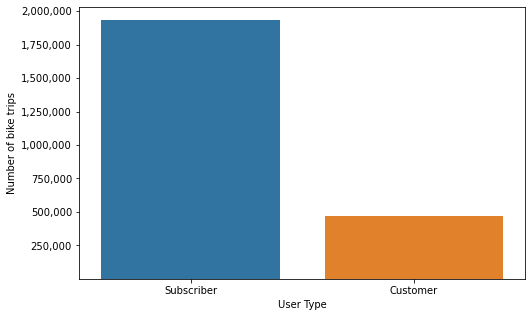

```python
plt.figure(figsize=[8, 5])
sb.countplot(data=df_clean, x='user_type');
plt.yticks([25e4, 50e4, 75e4, 100e4, 125e4, 150e4, 175e4, 200e4], [ '250,000','500,000', '750,000', '1,000,000','1,250,000', '1,500,000', '1,750,000', '2,000,000']);
plt.xlabel('User Type')
plt.ylabel('Number of bike trips')
plt.show();
```

Subsriber users seems to have more trips than Customer users.

**Now let's explore the distribution of two important numeric variable which are `duration_min` and `distance_km`**

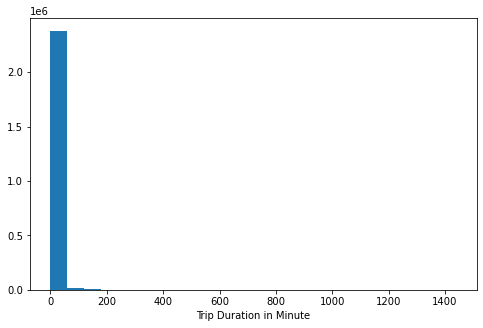

```python
# start with a standard-scaled plot
binsize = 60
bins = np.arange(0, df_clean['duration_min'].max()+binsize, binsize)
plt.figure(figsize=[8, 5])
plt.hist(data = df_clean, x = 'duration_min', bins = bins)
plt.xlabel('Trip Duration in Minute');
plt.show();
```

From the histogram above we can see that most trips have duration within 200 minutes, moreover there is some trips with more than 1000 which might are outliers.

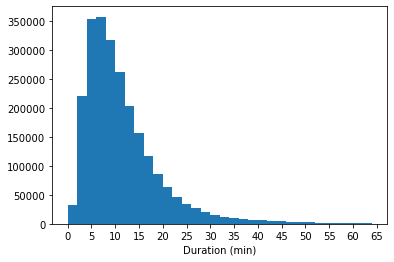

```python
#trips with duration less then 65 minutes
bins = np.arange(0, 66, 2)
ticks = np.arange(0, 66, 5)
plt.hist(data=df_clean, x='duration_min', bins=bins);
plt.xticks(ticks, ticks);
plt.xlabel('Duration (min)');
```

**The distribution of trips less then 65 minutes is skewed to the right with most of trips is less then 30 minutes**

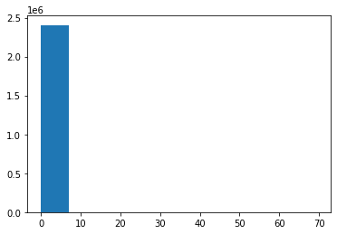

```python
#distrubtion of distance in standard-scaled
plt.hist(data = df_clean, x ='distance_km');
```

For the distance variable the plot above shows that users tend to ride bikes withing a distance of 10 kilometers, with an occurance of significant amout of outliers.It will be much helpful to limit the x axis to 10 kilometers to explore the distribuiton of distance further more.

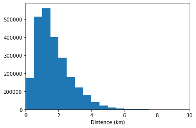

```python
#limit the x axis to 10 kms
bins = np.arange(0,10+.1, 0.5)
plt.hist(data = df_clean, x = 'distance_km',bins=bins)
plt.xlim(0,10)
plt.xlabel('Distence (km)');
```

The distribution of distance in kilometers is skewed to the right, with most of data points within 2 kilometers.

**Now we will move to discover the number of trips by dates variable(months, day of week, hour of day)**

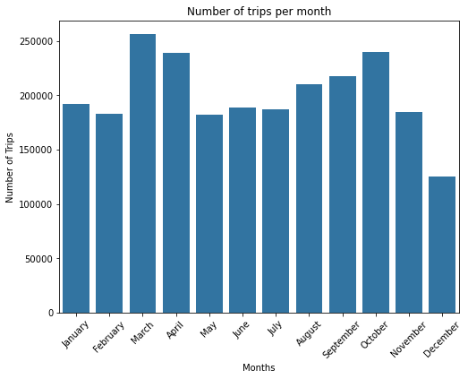

```python
#Monthly trips
plt.figure(figsize = [8, 6])
color = color=sb.color_palette()[0]

sb.countplot(data=df_clean,x='start_month', color=color)
plt.xticks(rotation=45)
plt.xlabel('Months')
plt.ylabel('Number of Trips')
plt.title('Number of trips per month');
```

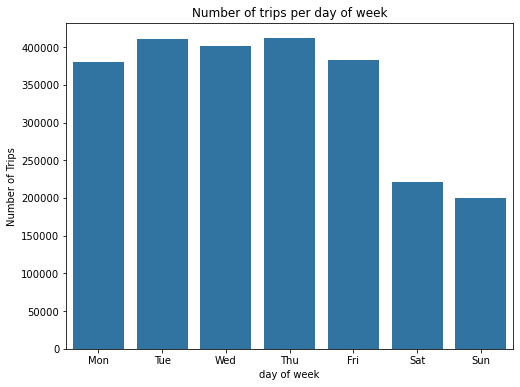

```python
#trips by day of week
plt.figure(figsize = [8, 6])

sb.countplot(data=df_clean,x='start_dayofweek', color=color)
plt.xlabel('day of week')
plt.ylabel('Number of Trips')
plt.title('Number of trips per day of week');
```

[figure not shown]

```python
#trips by hours
plt.figure(figsize = [8, 6])
sb.countplot(data=df_clean,x='start_hour', color=color)
plt.xlabel('Hours')
plt.ylabel('Number of Trips')
plt.title('Number of trips per Hour of day');
```

### Discuss the distribution(s) of your variable(s) of interest. Were there any unusual points? Did you need to perform any transformations?

By looking at each variable by it self we can say that:

- the `user_type` variable has only two categories subscriber and customer, but most of trips were taken by subscribers.
- the `duration_min` variable look unimodal with majority of trips is within 200 minutes, after limiting only about one hour trips the distribution look skewed to the right with long tail. That suggests an occurrence of outliers up to 24 hours.
- The number of trips in the Spring and Autumn seems more than the rest of the year, also during weekdays (Monday to Friday then weekends (Saturday and Sunday).

### Of the features you investigated, were there any unusual distributions? Did you perform any operations on the data to tidy, adjust, or change the form of the data? If so, why did you do this?

In the both distributions of duration_min and distance_km we perform an x axis limit to focus only on trips within one hour and 10 kilometers since there is a mush data point that are considered lighters in both variables.

## Biavariate Exploration

In this part of exploration, I will investigate how the number of trips is changing according to date features and user type. Moreover, I will be focusing particularly in the distribution of distance and duration in each month, day of the week and hour of the day. And since most of the trip's duration in less than one hour we will focus only of that part.

```python
samples = np.random.choice(df_clean.shape[0], 50000, replace = False)
df_sample = df_clean.iloc[samples,:]
```

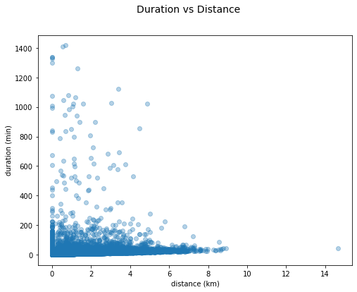

```python
#sample 50000 data point so that plots are clearer and they render faster

plt.figure(figsize = [8, 6])
plt.scatter(data = df_sample, x = 'distance_km', y = 'duration_min', alpha = 1/3)
plt.xlabel('distance (km)')
plt.ylabel('duration (min)')
plt.suptitle('Duration vs Distance ', size = 14)
plt.show();
```

Plotting the `duration_min` against `distance_km` from a sample of data did not reveal any relationship between these two variable.

Now let's look how the number of trips varies in date variable for each user type.

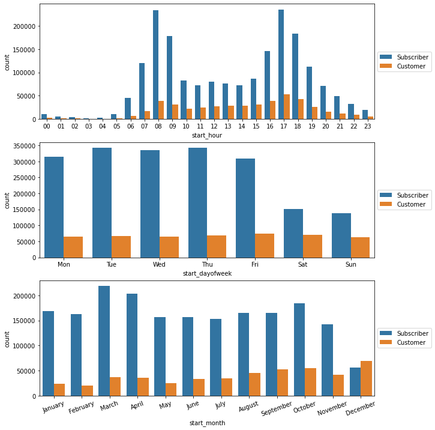

```python
#create stacked bar chart for each variable of start_time by user type
plt.figure(figsize = [10, 12])
ticks_rotation = 20

# subplot 1:
plt.subplot(3, 1, 1)
sb.countplot(data=df_clean,x='start_hour', hue='user_type')
plt.legend(loc = 6, bbox_to_anchor = (1.0, 0.5))


# subplot 2:
plt.subplot(3, 1, 2)
sb.countplot(data=df_clean,x='start_dayofweek',hue='user_type')
plt.legend(loc = 6, bbox_to_anchor = (1.0, 0.5))


# subplot 3:
plt.subplot(3, 1, 3)
sb.countplot(data=df_clean,x='start_month',hue='user_type')
plt.xticks(rotation=ticks_rotation)
plt.legend(loc = 6, bbox_to_anchor = (1.0, 0.5))
plt.show();
```

As mentioned earlier the number of trips peaks during commute hours in the morning and afternoon, but this time the first plot shows that out of commute hours the **Customers** trips almost stayed stable

Let's move to see how the distribution of trips duration varies in each month.

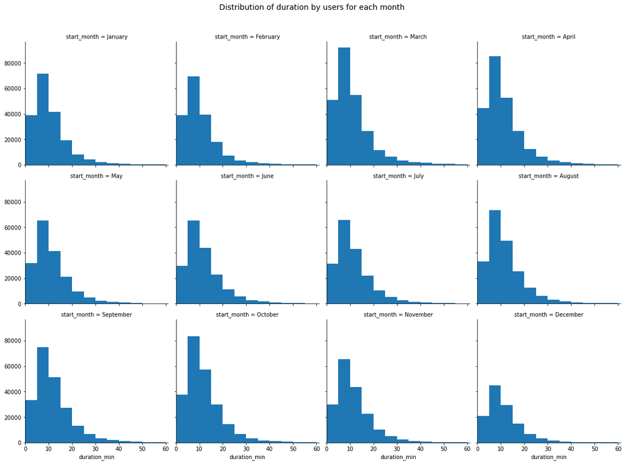

```python
#plot a Facet grid of the distribution of trips duration in each month

bins = np.arange(0, 61, 5)
g = sb.FacetGrid(data = df_clean, col = 'start_month', col_wrap = 4, height=4, aspect=1)
g.map(plt.hist, 'duration_min',bins=bins);
g.set(xlim=(0, 61))
g.fig.suptitle('Distribution of duration by users for each month', size = 14)
g.fig.subplots_adjust(top=0.9);
```

The distribution of trips duration in each month looks similar from month to month and doesn't seem to be any difference.Let's see if these changes by day of the week.

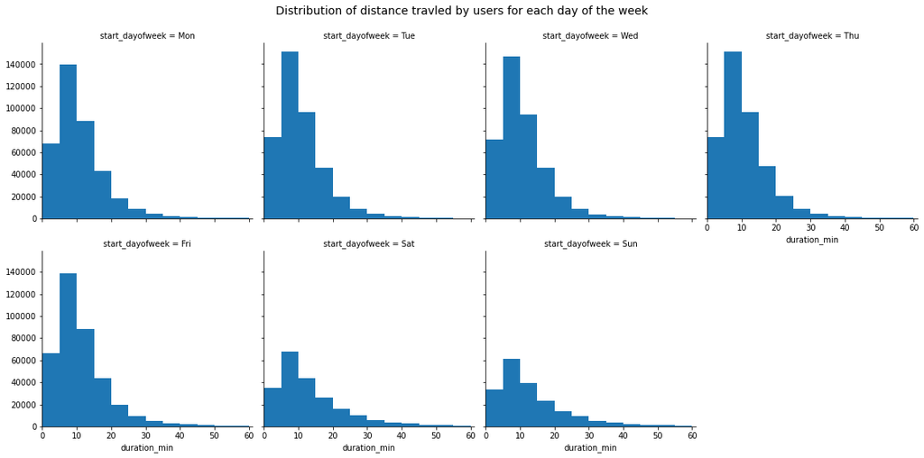

```python
#plot a Facet grid of the distribution of duration in each day of week

bins = np.arange(0, 61, 5)
g = sb.FacetGrid(data = df_clean, col = 'start_dayofweek', col_wrap = 4, height=4, aspect=1,hue_order='start_dayofweek')
g.map(plt.hist, 'duration_min',bins=bins);
g.set(xlim=(0, 61))
g.fig.suptitle('Distribution of distance travled by users for each day of the week', size = 14)
g.fig.subplots_adjust(top=0.9);
```

Before closing this section, we'll take a look at trip duration for each user type, for that we will select only trips within 10 kilometers and less then 1 hour to get remove outliers from the plot

```python
#trips with one hour duration and less than 10km distance.
df = df_clean.loc[(df_clean.duration_min < 61) & (df_clean.distance_km < 11)]
```

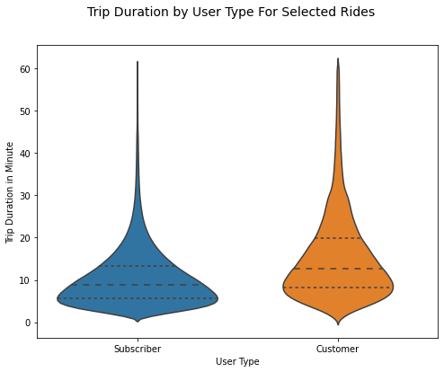

```python
plt.figure(figsize = [8, 6])
sb.violinplot(data=df, x='user_type', y='duration_min', inner='quartile');
plt.xlabel('User Type');
plt.ylabel('Trip Duration in Minute')
plt.suptitle('Trip Duration by User Type For Selected Rides', size = 14)
plt.show();
```

After removing the outliers the trip duration distribution is much narrower for subscribers compared to Customer riders with the shorter/quicker trip end overall. It seems like subscribers have a more specific usage or targeted goal riding the bikes compared to customers who vary more and generally used the bikes for longer.

### Did you observe any interesting relationships between the other features (not the main feature(s) of interest)?

We investigated if there is any realtionhsip between the distance traveled and the duration of the ride, but there doesn't seem to be any of that.

## Multiavariate Exploration

We saw earlier in the Bivariate exploration section that the correlation between distance and duration is very weak, this time we will check if there is a correlation between these variable if we split the data by user type.

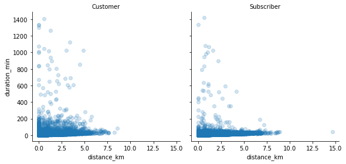

```python
#plot a Facet grid of the scatter plot of duration vs distance
#sample 50000 data point so that plots are clearer and they render faster

g = sb.FacetGrid(data = df_sample, col = 'user_type', height = 4,col_wrap = 3)
g.map(sb.regplot, 'distance_km', 'duration_min', y_jitter = 0.04, fit_reg = False,scatter_kws = {'alpha' : 1/5})
g.set_titles('{col_name}');
```

We tried looking at a faceted scatter plot across user type, but it seems like there is no correlation in each type. Maybe the duration in each day of week by user type will reveal an interesting trend.

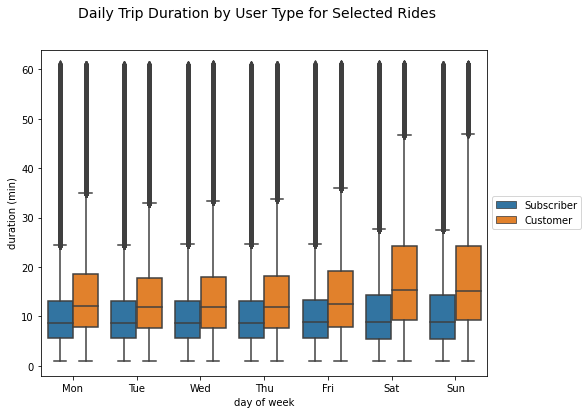

```python
plt.figure(figsize = [8, 6])
sb.boxplot(data=df,x='start_dayofweek',y='duration_min',hue='user_type')
plt.xlabel('day of week')
plt.ylabel('duration (min)');
plt.legend(loc = 6, bbox_to_anchor = (1.0, 0.5))
plt.suptitle('Daily Trip Duration by User Type for Selected Rides', size = 14)
plt.show();
```

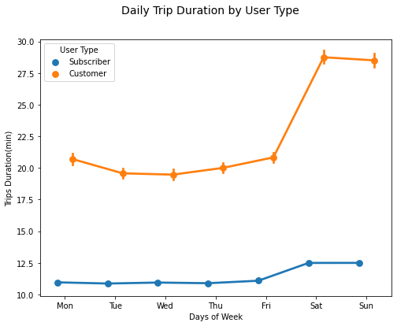

```python
plt.figure(figsize = [8, 6])
sb.pointplot(data=df_clean, x='start_dayofweek', y='duration_min', hue='user_type', dodge=0.3);
plt.xlabel('Days of Week');
plt.ylabel('Trips Duration(min)')
plt.legend(title='User Type')
plt.suptitle('Daily Trip Duration by User Type', size = 14)
plt.show();
```

The point plot above is an excellent visual showing the difference between customers and subscribers, where consumers use the bike share system for a relatively long period of time about 20 minutes on weekdays, with a significant increase up to 30 minutes on weekends. In the other hand, subscribers have sustained usage about 11 minutes on weekdays with a gradual increase to 12 minutes in weekends.

Finally, let's look at the relationship between user type and start time of trips

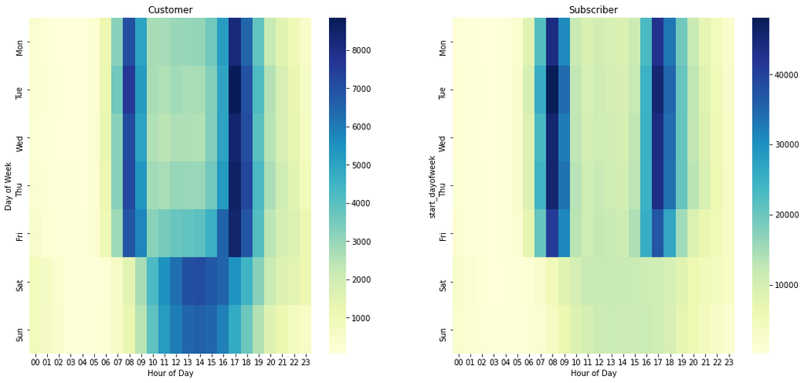

```python
# heatmap
plt.suptitle('Hourly Usage during Weekdays for Customers and Subscribers')
fig, ax = plt.subplots(ncols = 2, figsize = [18,8])


plt.subplot(1, 2, 1)
customers = df_clean.query('user_type == "Customer"')
ct_counts = customers.groupby(['start_dayofweek', 'start_hour']).size()
ct_counts = ct_counts.reset_index(name='count')
ct_counts = ct_counts.pivot(index='start_dayofweek', columns='start_hour', values='count')
sb.heatmap(ct_counts, cmap='YlGnBu')
plt.title('Customer', loc='center');
plt.xlabel('Hour of Day')
plt.ylabel('Day of Week')

plt.subplot(1, 2, 2)
subscribers = df_clean.query('user_type == "Subscriber"')
st_counts = subscribers.groupby(['start_dayofweek', 'start_hour']).size()
st_counts = st_counts.reset_index(name='count')
st_counts = st_counts.pivot(index='start_dayofweek', columns='start_hour', values='count')
sb.heatmap(st_counts, cmap='YlGnBu')
plt.title('Subscriber', loc='center')
plt.xlabel('Hour of Day')
```

### Talk about some of the relationships you observed in this part of the investigation. Were there features that strengthened each other in terms of looking at your feature(s) of interest?

The multivariate exploration reinforced some of the trends found in the previous bivariate and univariate exploration, the relationship between the plotted multiple variables is thoroughly visualized and the information is presented in combination. The efficient / short use duration for subscribers corresponds to their high concentration on Monday through Friday rush hours, suggesting that the use is mainly for work commutes.

### Were there any interesting or surprising interactions between features?

All the interactions between features complement each other and make very sense when looked at in combination. An significant finding was the relationship between the distance traveled and the duration of the ride.  
We expected some correlation between distance and duration. However, the data showed that particularly between user types, there is no obvious relationship between the two variables.